# Workshop Candy Trade

```r
library(rmarkdown)
library(ggplot2)
library(knitr)
```

1. **Pre-trade**: Participants were asked to rate the happiness of their candy selection on a scale from 1-10 (trade 0).
2. **Trade 1**: Participants were then allowed to trade with one participant and rate the happiness with their selection following the trade on a scale from 1-10 (trade 1).
3. **Trade 2**: Participants were then allowed to trade with the whole group and rate their happiness with their final selection on a scale from 1-10 (trade 2).

Our data was collected using a [google form](https://goo.gl/forms/Mxi2fKrOYc9UCB9j1). For each trade, the participants contributed their name (*“participant_name”*), which trade they had just finished (*“trade_number”*), and their current happiness with their candy selection (*“happiness_rating”*).

## Happiness rating vs. number of trades

To explore the trends in individual candy selection happiness over the trades, we created a simple line plot.

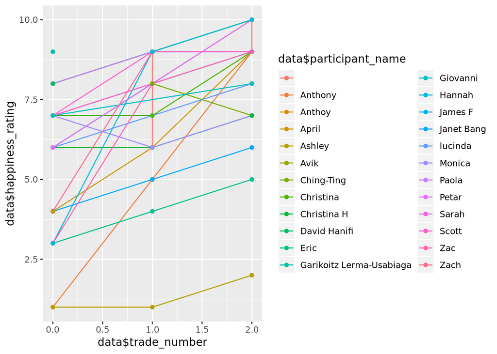

```r
myPlot = ggplot(data, aes(data$trade_number,
    data$happiness_rating,colour=data$participant_name)) +
    geom_line() +
    geom_point()
plot(myPlot)
```

## Changes in candy selection happiness of our workshop group

Finally, we explored whether happiness changed significantly as a group over the trades using a boxplot.

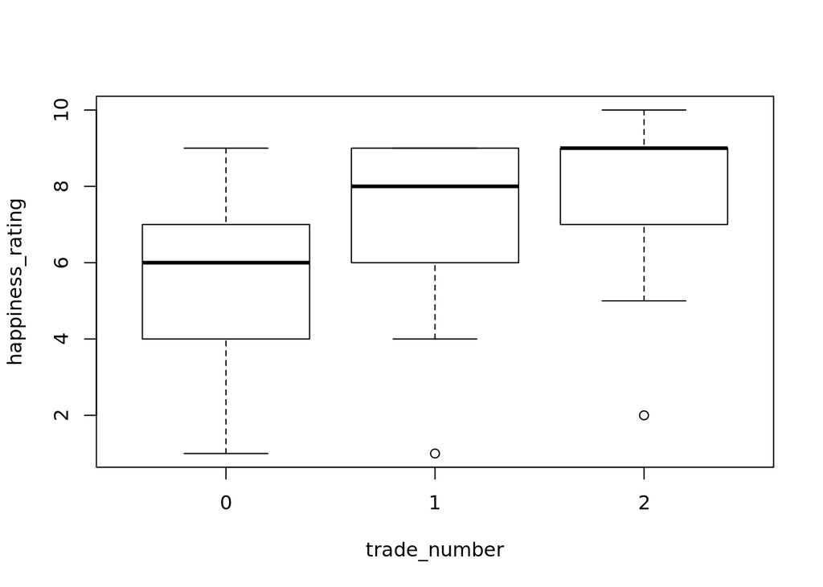

```r
boxplot(happiness_rating ~ trade_number, data = data)
```